# HSC Survey Results

## Survey Results

### Main Results

The results are subject to change as DFO will re-evaluate data editing, area estimation and apply a target strength.

**Preliminary biomass prediction for Scots Bay using standardized parallel transects is 4,392mt, and with turnover applied 3,323mt.**

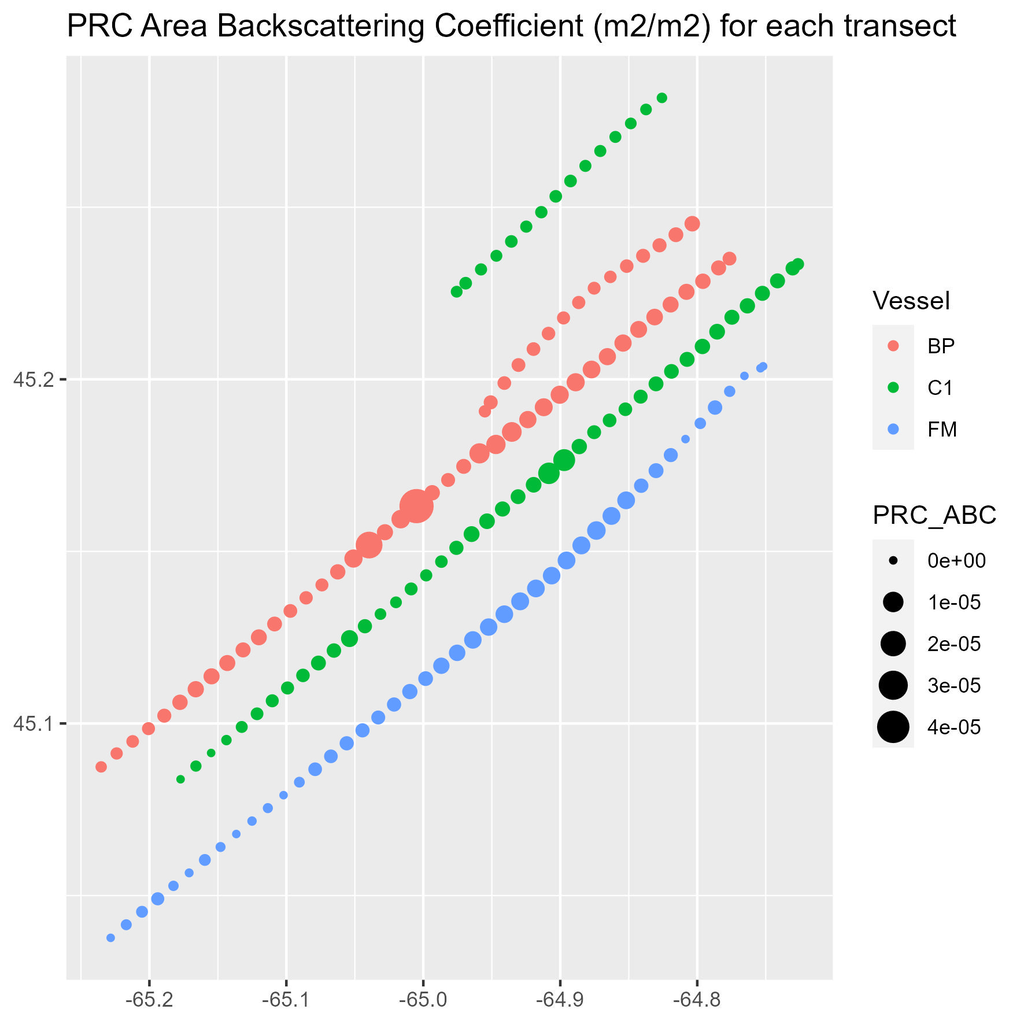

### Transect Details

Table 1: Transect Details

| Vessel | Transect # | Date/Time Start | Date/Time End | Start Lon | Start Lat | End Lon | End Lat | Location | Distance (km) | Speed |
| --- | --- | --- | --- | --- | --- | --- | --- | --- | --- | --- |
| BP | T01 | 2022-10-03 22:34:41 | 2022-10-04 01:18:43 | -65.247 | 45.085 | -64.776 | 45.235 | SB | 40.67 | 8.03 |
| BP | T02 | 2022-10-04 01:25:41 | 2022-10-04 02:03:34 | -64.792 | 45.248 | -64.955 | 45.191 | SB | 14.40 | 12.31 |
| C1 | T01 | 2022-10-03 22:56:41 | 2022-10-04 01:42:12 | -65.184 | 45.082 | -64.726 | 45.233 | SB | 40.91 | 8.01 |
| C1 | T02 | 2022-10-04 02:09:47 | 2022-10-04 02:56:12 | -64.820 | 45.283 | -64.976 | 45.225 | SB | 14.11 | 9.85 |
| FM | T01 | 2022-10-05 05:43:41 | 2022-10-05 08:37:04 | -65.231 | 45.037 | -64.752 | 45.204 | SB | 42.41 | 7.92 |

### Survey Summary

Table 2: Acoustic Survey Results

| Vessel | Transect No. | Target Strength (db/kg) | Mean Sa (/m2) | Biomass Density (kg/m2) |
| --- | --- | --- | --- | --- |
| BP | T01 | -35.5 | -52.536 | 0.020 |
| C1 | T01 | -35.5 | -55.742 | 0.009 |
| FM | T01 | -35.5 | -55.994 | 0.009 |
| BP | T02 | -35.5 | -57.109 | 0.007 |
| C1 | T02 | -35.5 | -60.191 | 0.003 |

Note:  
Transects are listed from greatest to least backscatter.

Table 3: Survey Summary Table

| Layer | Target Strength | Area (km2) | Mean Sa | Density (kg/m2) | Biomass (tons) | Percent Area | Percent Biomass | Standard Error (tons) | Standard Error (%) |
| --- | --- | --- | --- | --- | --- | --- | --- | --- | --- |
| Main Box | -35.5 | 390 | -54.9836 | 0.0097 | 4,392.389 | 100 | 100 | 1,067.99 | 24.31 |

### Greatest Backscatter

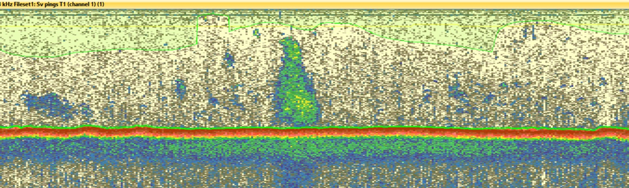

A snip from the transect with the greatest backscatter

The single point with the largest backscatter density (PRC) was recorded by **BP**, at the following location:

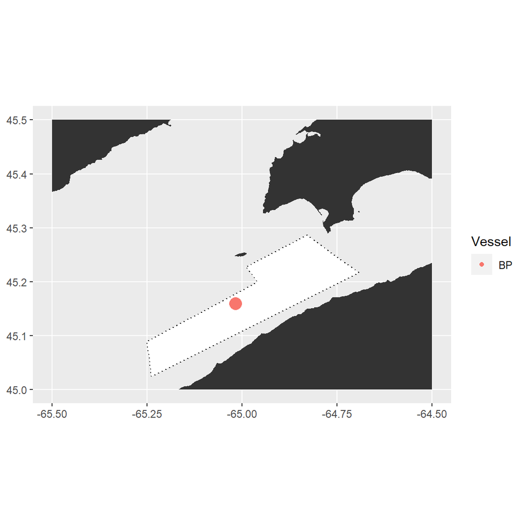

The transect with the overall largest biomass was recorded by **BP**, at the following location:

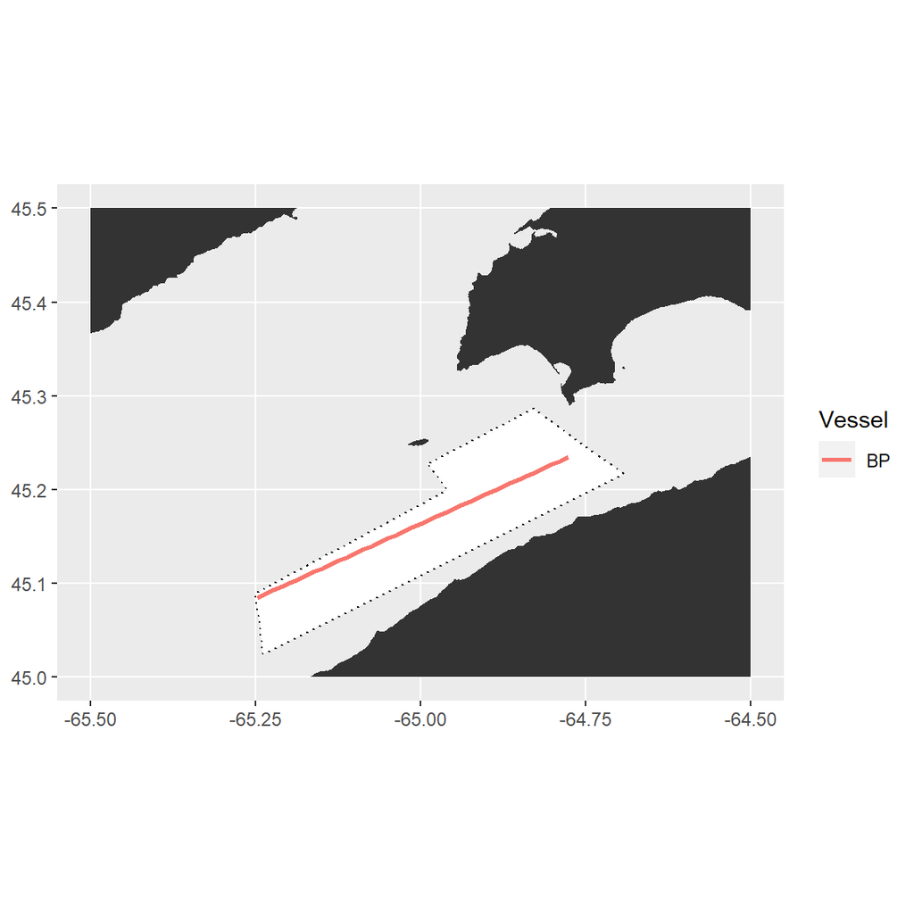

### Annual Summaries

Table 4: Annual Comparison Table

| Ground | Survey Number | Current Year Survey Date | Current Year HSC Estimate | Current Year HSC Turnover Adjusted | Previous Year Survey Date | Previous Year HSC Estimate | Previous Year HSC Turnover Adjusted | Previous Year DFO Estimate | Previous Year DFO Turnover Adjusted |
| --- | --- | --- | --- | --- | --- | --- | --- | --- | --- |
| Scots Bay | 1 | 2022-05-29 | 90,746.000 | 90,746 | 2021-05-24 | 4,502 | 4,502 | 3,269 | 3,270 |
| Scots Bay | 2 | 2022-06-12 | 104,368.000 | 92,111 | 2021-06-07 | 13,947 | 13,339 | 2,879 | 2,288 |
| Scots Bay | 3 | 2022-06-26 | 34,199.000 | 19,781 | 2021-06-19 | 7,056 | 4,685 | 3,739 | 3,268 |
| Scots Bay | 4 | 2022-07-10 | 10,537.000 | 5,549 | 2021-07-04 | 9,104 | 8,098 | 6,317 | 5,861 |
| Scots Bay | 5 | 2022-07-26 | 13,060.000 | 11,904 | 2021-07-17 | 4,985 | 3,602 | 2,949 | 1,994 |
| Scots Bay | 6 | 2022-08-07 | 5,250.000 | 3,067 | 2021-08-02 | 10,364 | 9,817 | 4,922 | 4,540 |
| Scots Bay | 7 | 2022-08-21 | 4,392.000 | 3,453 | 2021-08-15 | 7,705 | 6,159 | 4,670 | 4,006 |
| Scots Bay | 8 | 2022-09-05 | 21,908.000 | 21,372 | 2021-08-29 | 3,602 | 2,453 | 3,876 | 3,228 |
| Scots Bay | 9 | 2022-09-18 | 8,133.000 | 4,850 | 2021-09-13 | 38,584 | 38,109 | 38,224 | 36,587 |
| Scots Bay | 10 | 2022-10-03 | 4,392.389 | 3,323 | 2021-09-26 | 1,456 | 0 | 2,716 | 0 |

Table 5: Annual Summary Table

| Year | Ground | HSC Estimate | HSC Turnover Adjusted | DFO Estimate | DFO Turnover Adjusted |
| --- | --- | --- | --- | --- | --- |
| 2021 | Scots Bay | 101,305.0 | 90,764 | 73,561 | 65,042 |
| 2022 | Scots Bay | 296,985.4 | 256,156 | NA | NA |

## Tagging, Plankton, and CTD Data

### Tag Data

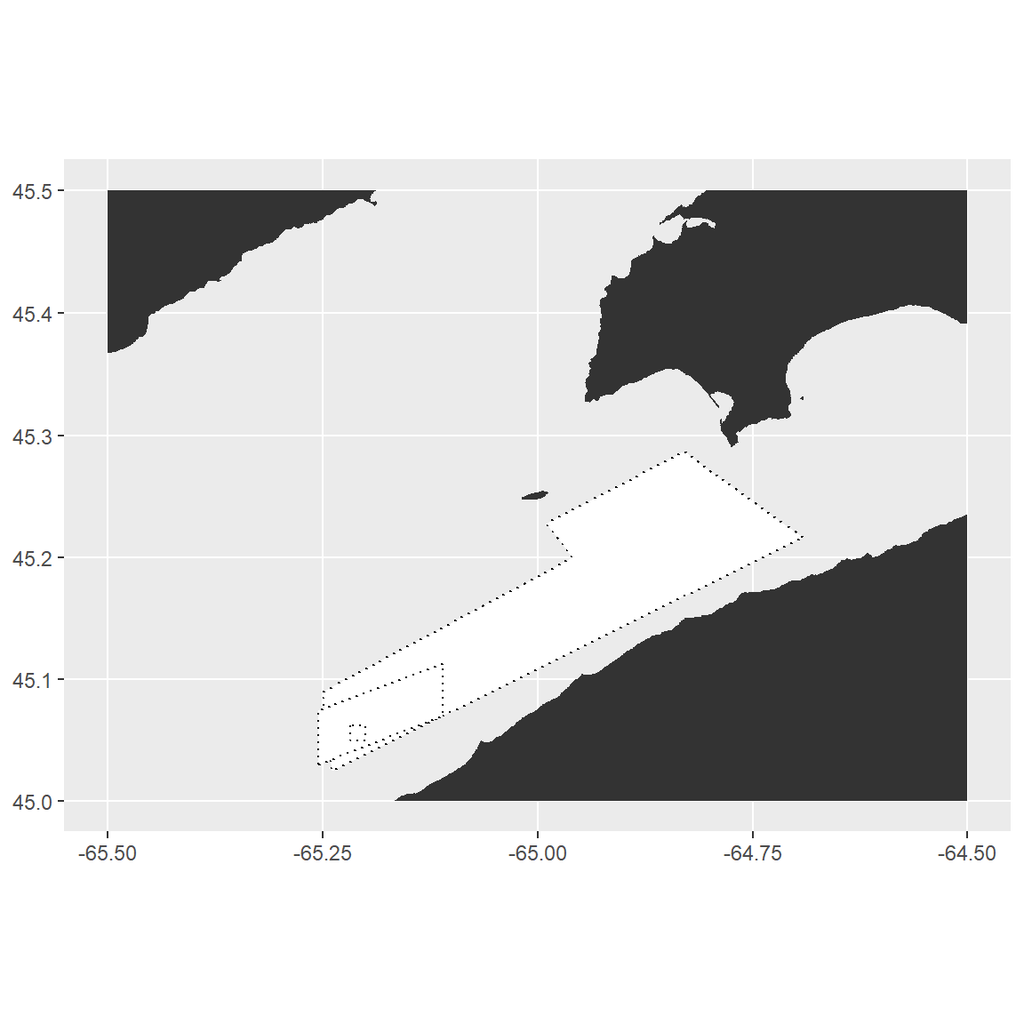

| Vessel | Tags |
| --- | --- |

### Plankton Data

#### Tow Summary Table

|  | Tow 1 | Tow 2 |
| --- | --- | --- |
| **Base Details** |  |  |
| Vessel | NA | NA |
| Set Number | SB2022 | SB2022 |
| Ground | SB | SB |
| Date | 02/10/2022 | 02/10/2022 |
| Wind Direction (km/h) | NA | NA |
| Swell (m) | NA | NA |
| Air Temp (c) | NA | NA |
| **Tow Details** |  |  |
| Tow Start | NA | NA |
| Tow End | NA | NA |
| Start Lat | NA | NA |
| End Lat | NA | NA |
| Start Lon | NA | NA |
| End Lon | NA | NA |
| Avg Tow Depth (m) | NA | NA |
| Speed | NA | NA |
| Heading | NA | NA |
| Tide Direction | NA | NA |
| **Other Data Collection** |  |  |
| Flow Start | NA | NA |
| Flow End | NA | NA |
| No. Revolutions | NA | NA |
| Distance (m) | NA | NA |
| Volume | NA | NA |
| Secchi Disappear (m) | NA | NA |
| Secchi Reappear (m) | NA | NA |

### CTD Data

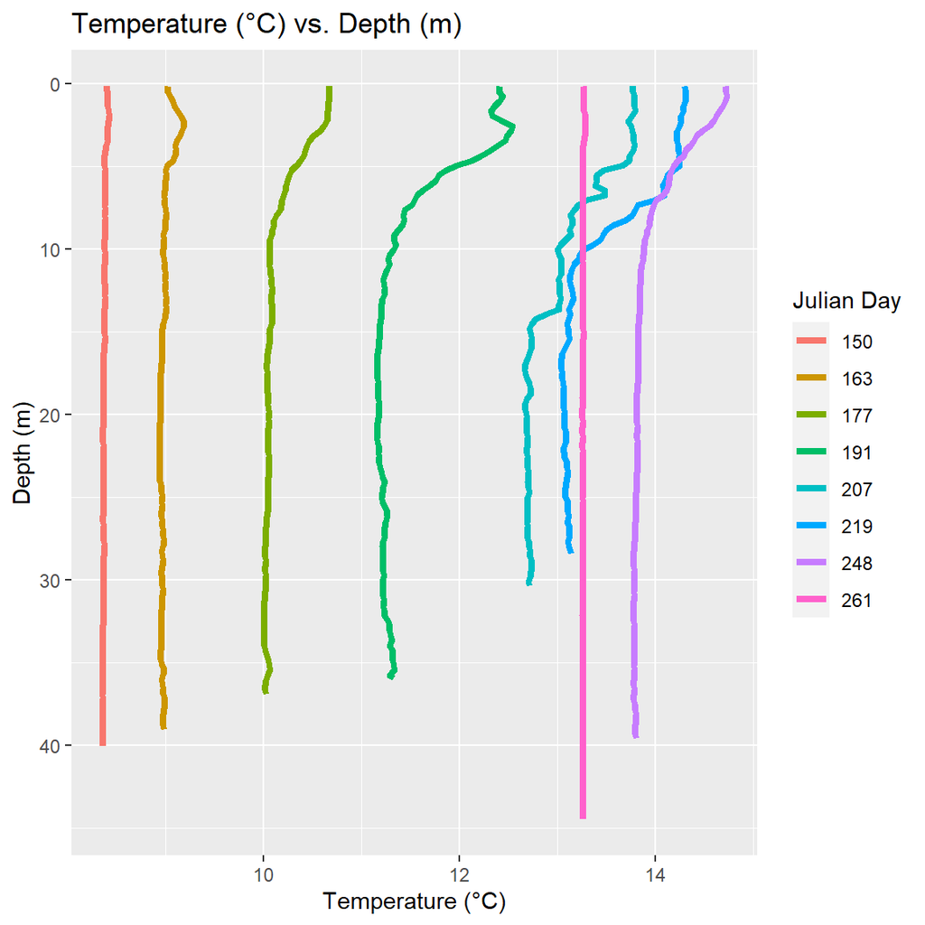

#### Sea surface temperatures

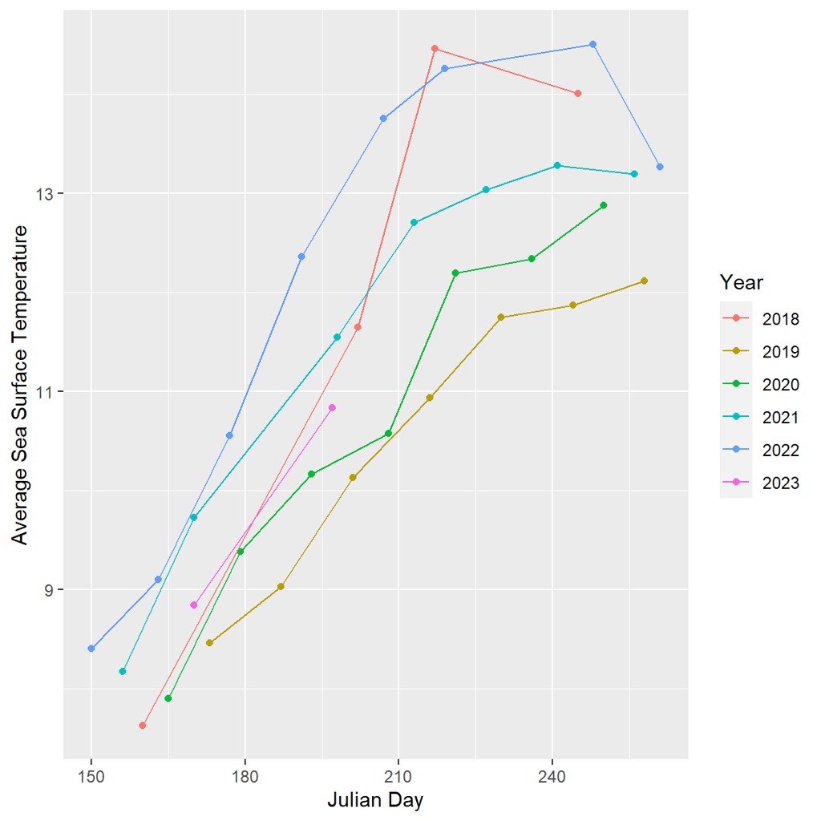

Annual average sea surface temperatures (SST) for Scots Bay.

## Vessel Performance

### Speed

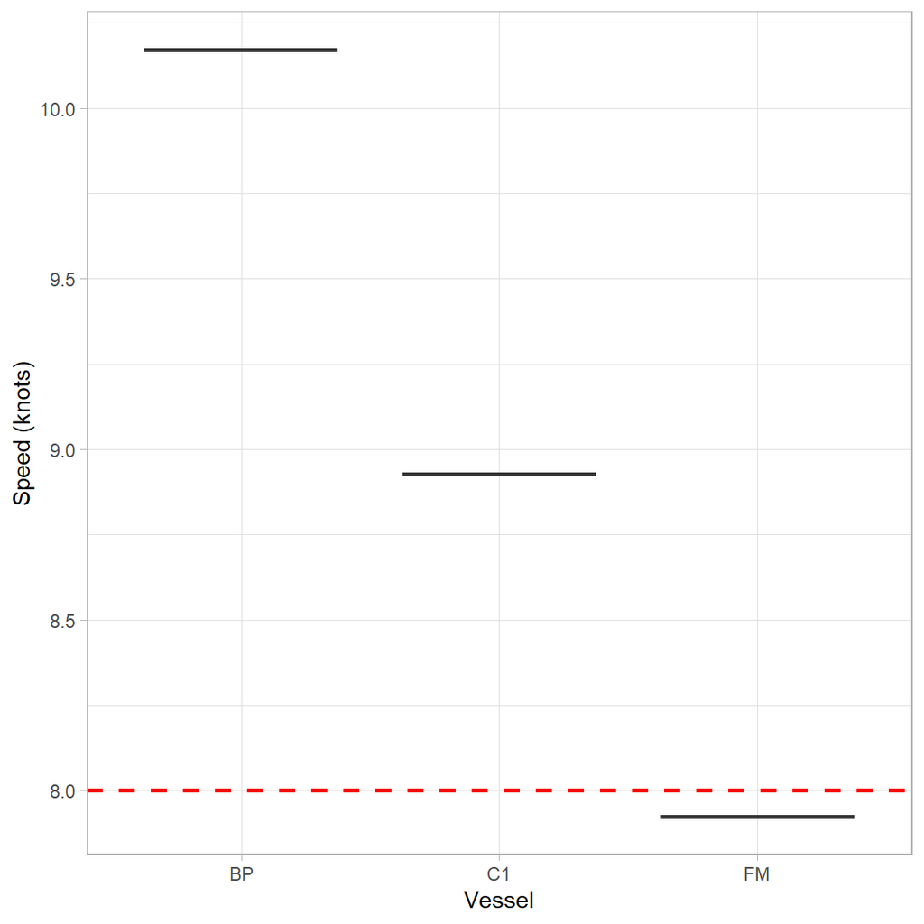

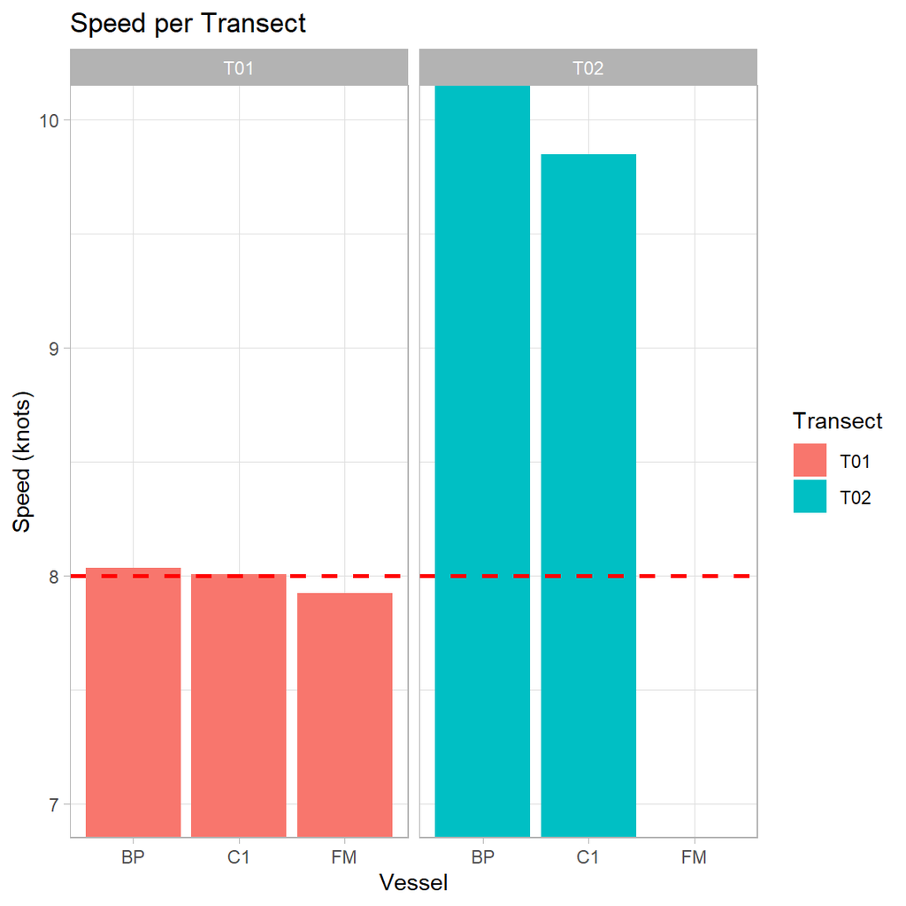

Average vessel speed was 9.01. This is above the 8 knot requirement; vessels are urged to slow down to prevent backscatter noise from interfering with the acoustic data.

### Distance

[figure not shown]

No significant distance was cut from the planned lines; vessels covered the planned area well.